# knn for handwritten digits prediction

#### Part 1.

Build a KNN to do handwritten digits prediction. The data consists of grey scale images of handwritten digits. Each image is a set of pixels stored as a vector.

```python
from sklearn.datasets import load_digits, load_wine
import numpy as np
import matplotlib.pyplot as plt
import pandas as pd
import numpy as np
import sklearn.datasets
import numpy as np
import pandas as pd
from sklearn.model_selection import train_test_split
from sklearn.metrics import  accuracy_score
import matplotlib.pyplot as plt
from sklearn.model_selection import KFold
%matplotlib inline
```

Load the MNIST dataset. (Can take up to 3 minutes.) `x` stores the images and `y` stores the labels. For an image i, $x_{i}$ is a vector of its pixel values, and $y_{i}$ is its label. $y_{i} \in [1,2,3,4,5,6,7,8,9,0] $ .

```python
mnist = sklearn.datasets.fetch_openml('mnist_784')
x = mnist.data.to_numpy(dtype= np.int64)
y = mnist.target.to_numpy(dtype= np.int64)
```

Separate training and testing data randomly.

```python
X_train, X_test, Y_train, Y_test = train_test_split(
    x[:2500], y[:2500], test_size=0.2, random_state=123, stratify=y[:2500])
print(X_train.shape)
print(X_test.shape)
print(Y_train.shape)
print(Y_test.shape)
```

```
(2000, 784)
(500, 784)
(2000,)
(500,)
```

#### 1.1

Instance method `fit` is the training process. For KNN it is simply storing the training dataset.

Instance method `distance` is a function that takes in two vectors (samples of data) and returns the distance between the two vectors. (1.5 points)

Instance method `predict` uses KNN method to predict a given set of digit images. If the input is a N by d dimensional matrix, where d is the number of features and N is the number of samples, the output should be an N dimensional vector.

Instance method `score` produces the accuracy of the KNN model when running on a test dataset. Accuracy is the precentage of the test data that is correctly classified. (Hint: you will first need to call `self.predict` to label the input test data.)

```python
class knn:
	def __init__(self, k):
		self.k = k
		self.X_train = None
		self.Y_train = None

	def fit(self, X, Y):
		self.X_train = X
		self.Y_train = Y

	def distance(self, x1, x2):

		# returns the distance between two vectors
		# the distance is the L2 norm
		return np.sqrt(np.sum((x1 - x2) ** 2))

	def predict(self, x_test):
		# returns the predictions for multiple examples X
		# your solution here
		predictions = []
		for x in x_test:
			distances = [self.distance(x, x_train) for x_train in self.X_train]
			k_indices = np.argsort(distances)[:self.k]
			k_nearest_labels = [self.Y_train[i] for i in k_indices]

            # Find the most common label without using Counter
			unique_labels, counts = np.unique(k_nearest_labels, return_counts=True)
			most_common_label = unique_labels[np.argmax(counts)]

			predictions.append(most_common_label)
		return np.array(predictions)

	def score(self, x_test, y_test):
		# Return the accuracy of your model on the test data.
		y_pred = self.predict(x_test)
		accuracy = np.mean(y_pred == y_test)
		return accuracy

	def training_score(self):
		y_pred = self.predict(self.X_train)
		accuracy = np.mean(y_pred == self.Y_train)
		return accuracy
```

Compare the accuracy using our KNN model with the accuracy using Sklearn KNN to see if we have implemented correctly. The two accuracy scores should be fairly close.

```python
from sklearn.neighbors import KNeighborsClassifier
sklearn_knn = KNeighborsClassifier(n_neighbors = 5)
sklearn_knn.fit(X_train, Y_train)
sklearn_knn_score = sklearn_knn.score(X_test, Y_test)
print("sklearn_knn_score:", sklearn_knn_score)

our_knn = knn(k = 5)
our_knn.fit(X_train, Y_train)
our_knn_score = our_knn.score(X_test, Y_test)
print("our_knn_score:", our_knn_score)
```

```
sklearn_knn_score: 0.912
our_knn_score: 0.912
```

Let's visualize the images that are being misclassifed and compare that to the ones that are correctly classifed. This will help us to see the potential problems of our model. You can change the code below to see more images.

```python
Y_pred = our_knn.predict(X_test)

incorrect = [i for i, x in enumerate(Y_pred!=Y_test) if x]
correct = [i for i, x in enumerate(Y_pred==Y_test) if x]
```

[output not shown]

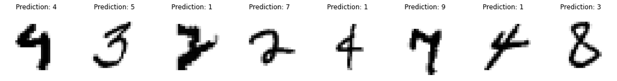

```python
NUM_OF_IMAGES = 8 # number of images to display
_, axes = plt.subplots(nrows=1, ncols=NUM_OF_IMAGES, figsize=(20, 20))
START = 0 # start index of the images to display
for ax, ind in zip(axes, list(range(START,START+NUM_OF_IMAGES))):
    ax.set_axis_off()
    image = X_test[incorrect[ind]].reshape(28, 28)
    ax.imshow(image, cmap=plt.cm.gray_r, interpolation="nearest")
    ax.set_title(f"Prediction: {Y_pred[incorrect[ind]]}")
```

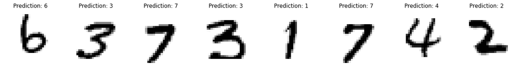

```python
_, axes = plt.subplots(nrows=1, ncols=NUM_OF_IMAGES, figsize=(20, 20))
START = 120 # start index of the images to display
for ax, ind in zip(axes, list(range(START,START+NUM_OF_IMAGES))):
    ax.set_axis_off()
    image = X_test[correct[ind]].reshape(28, 28)
    ax.imshow(image, cmap=plt.cm.gray_r, interpolation="nearest")
    ax.set_title(f"Prediction: {Y_pred[correct[ind]]}")
```

#### 1.2 Testing and Traning

Test the training and test accuracy using any sets of k values ($k \in \mathbb{Z}^{+}$, at least 5 k values in your set) and plot the results with the x axis as the values of the k values you picked and the y axis as the accuracies. You can plot it on two seperate graphs or on the same one. Make sure clearly label which one is for the training accuracy and which one is for the test accuracy. The type of graph you choose has to clearly indicate the trend you observe.

Good time to grab a coffee if it takes too long to run.

NOTE: Use the KNN model you built for this task. For generating training accuracy, you can add a new method similar to the `score` method but outputs training accuracy instead of test.

```
k=1, Training Accuracy: 1.0, Test Accuracy: 0.912
k=3, Training Accuracy: 0.959, Test Accuracy: 0.918
k=5, Training Accuracy: 0.9375, Test Accuracy: 0.912
k=7, Training Accuracy: 0.9305, Test Accuracy: 0.916
k=9, Training Accuracy: 0.921, Test Accuracy: 0.898
```

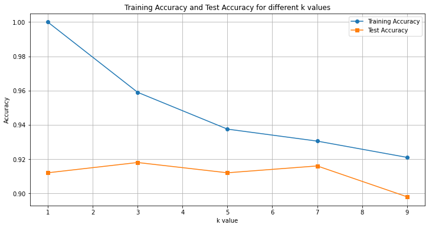

```python
# Code for plots (2 points as mentioned above)
k_values = [1, 3, 5, 7, 9]
training_accuracies = []
test_accuracies = []

for k in k_values:
    knn_model = knn(k=k)
    knn_model.fit(X_train, Y_train)

    training_accuracy = knn_model.training_score()
    test_accuracy = knn_model.score(X_test, Y_test)

    training_accuracies.append(training_accuracy)
    test_accuracies.append(test_accuracy)

    print(f"k={k}, Training Accuracy: {training_accuracy}, Test Accuracy: {test_accuracy}")

plt.figure(figsize=(12, 6))
plt.plot(k_values, training_accuracies, marker='o', label='Training Accuracy')
plt.plot(k_values, test_accuracies, marker='s', label='Test Accuracy')
plt.xlabel('k value')
plt.ylabel('Accuracy')
plt.title('Training Accuracy and Test Accuracy for different k values')
plt.legend()
plt.grid(True)
plt.show()
```

Choose one other distance function from below or create your own distance function. Below is a list of distance functions that you could try. You can use the optimal k-value from Q1.2; however, in real world, we would need to find the optimal k value again with the new distance function. Create a new `knn` class if you need to, but necessary.

1. Manhattan Distance
2. Cosine Distance
3. L-Infinity norm

```python
"""
You can use built-in Numpy methods to implement your distance forumla but be sure to understand what equations those methods are using.
"""
# Write the Python implementation here (1.5 points)
class knn_manhattan:
    def __init__(self, k):
        self.k = k
        self.X_train = None
        self.Y_train = None
    def fit(self, X, Y):
        self.X_train = X
        self.Y_train = Y
    def distance(self,x1,x2):
        return np.sum(np.abs(x1 - x2))
    def predict(self, x_test):
        num_test = x_test.shape[0]
        y_pred = np.zeros(num_test)
        for i in range(num_test):
            distances = np.array([self.distance(x_test[i], x_train) for x_train in self.X_train])
            knn_indices = np.argsort(distances)[:self.k]
            knn_labels = self.Y_train[knn_indices]
            y_pred[i] = np.argmax(np.bincount(knn_labels))
        return y_pred
    def score(self, x_test, y_test):
        y_pred = self.predict(x_test)
        accuracy = np.mean(y_pred == y_test)
        return accuracy
    def training_score(self):
        y_pred = self.predict(self.X_train)
        accuracy = np.mean(y_pred == self.Y_train)
        return accuracya
```

**Write answers to the below questions**

What is your distance function? Write down the distance equation. (0.5 point)  
Answer:Manhattan Distance. Distance equation is the sum of absolute distance between two points. np.sum(np.abs(x1 - x2))

Describe issues with using the L2 norm: (2 points)  
Answer:The L2 norm is very sensitive to outliers because it squares the difference between the coordinates. If two points are far away,they can significantly influence the calculation of the distance and the predictions. Additionally, it is very computationally expensive as it requires computing the square root of the sum of squared differences.

### Problem 2

In this problem , we will be using the wine classfication dataset. Before opimizing our KNN model, it is imperative to understand the properties of our dataset.

More information about the dataset is linked below:

https://archive.ics.uci.edu/ml/datasets/wine

```python
wine = load_wine()
X = wine.data
print(X.shape)
Y = wine.target
print(Y.shape)
print("feature names:", wine.feature_names)
print("target names:", wine.target_names)
```

```
(178, 13)
(178,)
feature names: ['alcohol', 'malic_acid', 'ash', 'alcalinity_of_ash', 'magnesium', 'total_phenols', 'flavanoids', 'nonflavanoid_phenols', 'proanthocyanins', 'color_intensity', 'hue', 'od280/od315_of_diluted_wines', 'proline']
target names: ['class_0' 'class_1' 'class_2']
```

#### 2.1 (3 points)

Now, let’s classify the wine dataset using our KNN with the L2 norm as the distance function. Choose the optimal k value for this task and record your approach.

You might need to change the k value a couple of times to find the one with the highest average test accuracy. Feel free to add a for loop.

Since we have limited data, we can use K-folds to assess the performance of our model more accurately.

Note: KFold is a tool from Sklearn that helps you prepare your data for k-fold cross-validation (I know, the letter k is a little overused... K-fold, K-NN, K-means...) This line of code creates an instance of the tool with k, the number of folds, equals 5, which means each fold is 1/5 the size of the entire dataset. For each fold, we take the fold as the test set and the rest as the training set. When `n_splits` = 5, we will " train" the KNN 5 times and "test" it 5 times. Exactly which sample goes into which fold is random. (parameter `shuffle = True`) Link to documentation: https://scikit-learn.org/stable/modules/generated/sklearn.model_selection.KFold.html

For each k value, store accuracy of each test in a list so we can take the average of the accuracy scores. Each list should be `n_splits` long. Use the averages to determine the optimal k value.

NOTE: Use the KNN model you built for this task.

```python
kf = KFold(n_splits=5, shuffle=True, random_state=123) # Do not change the arguments.

# Your implementation to finding the optimal k value below
k_values = range(1, 21)
average_accuracies = []
for k in k_values:
    fold_accuracies = []
    for train_index, test_index in kf.split(X):
        X_train, X_test = X[train_index], X[test_index]
        Y_train, Y_test = y[train_index], y[test_index]
        knn_model = knn(k=k)
        knn_model.fit(X_train, Y_train)

        fold_accuracy = knn_model.score(X_test, Y_test)
        fold_accuracies.append(fold_accuracy)

    average_accuracy = np.mean(fold_accuracies)
    average_accuracies.append(average_accuracy)

    print(f"k={k}, Average Accuracy: {average_accuracy}")



optimal_k = k_values[np.argmax(average_accuracies)]
print("The optimal k value is {}.".format(optimal_k))
```

```
k=1, Average Accuracy: 0.04492063492063492
k=2, Average Accuracy: 0.05603174603174603
k=3, Average Accuracy: 0.07857142857142857
k=4, Average Accuracy: 0.07317460317460317
k=5, Average Accuracy: 0.073015873015873
k=6, Average Accuracy: 0.062063492063492064
k=7, Average Accuracy: 0.05063492063492063
k=8, Average Accuracy: 0.05047619047619047
k=9, Average Accuracy: 0.0334920634920635
k=10, Average Accuracy: 0.05587301587301587
k=11, Average Accuracy: 0.05603174603174603
k=12, Average Accuracy: 0.04492063492063492
k=13, Average Accuracy: 0.06158730158730159
k=14, Average Accuracy: 0.05063492063492063
k=15, Average Accuracy: 0.07285714285714286
k=16, Average Accuracy: 0.06158730158730159
k=17, Average Accuracy: 0.050317460317460316
k=18, Average Accuracy: 0.05587301587301587
k=19, Average Accuracy: 0.0673015873015873
k=20, Average Accuracy: 0.06174603174603175
The optimal k value is 3.
```

#### 2.2 (4 points)

Again, we would like to change our distance function to best fit our classification problem. Choose a distance function from what we have listed. It can be the same one from problem 1.3 . Set k equal to the optimal k value you have found.

(It is okay if the new distance function performs worse than using the L2 norm. You just need to write the new distance function and apply KNN to the dataset.)

```python
# Python implementation (1.5 points)
# You can keep the code you wrote for testing the new distance function.
kf = KFold(n_splits=5, shuffle=True, random_state=123)

optimal_k = 3
fold_accuracies = []

for train_index, test_index in kf.split(X):
    X_train, X_test = X[train_index], X[test_index]
    y_train, y_test = y[train_index], y[test_index]
    knn_model = knn_manhattan(k=optimal_k)#using the manhattan distance model we built earlier
    knn_model.fit(X_train, y_train)

    fold_accuracy = knn_model.score(X_test, y_test)
    fold_accuracies.append(fold_accuracy)

average_accuracy = np.mean(fold_accuracies)
print(f"Average Accuracy with Manhattan Distance (k={optimal_k}): {average_accuracy}")
```

```
Average Accuracy with Manhattan Distance (k=3): 0.06746031746031746
```

**Write answers to the below questions**

What is your distance function? Write down the distance equation. (0.5 point)  
Answer:Manhattan Distance. Distance equation is the sum of absolute distance between two points. In python, it can be written as np.sum(np.abs(x1 - x2)).

What do you think is the reason your distance function performs better or worse than the L2 norm? (2 points)  
Answer: The Manhattan Distance function performs worse than the L2 norm distance function, because it has a lower average accuracy(even though simply by comparing the accuracy can't tell the whole story, it's a reasonable indicator that we could look at). This difference in performance might be caused by different data characteristics. For example, if the data naturally forms spherical clusters, Euclidean distance is more effective because it measures the straight-line distance between points.

#### 2.3 (3 points)

We can further improve the accuracy of our model by normalizing the dataset.

Data can be normalized using the following equation:

$$ x_{ij}^{normalized} = \frac{x_{ij} -\mu_{j}}{\sigma_{j}} $$

Where $x_{ij}$ is the value of feature j of sample i,

$\mu_{j} $ and $\sigma_{j}$ are the mean and the standard deviation of feature j.

Normalize the wine dataset and apply your KNN model (with your favorite k value and distance function) on the normalized dataset.

Print the new average test accuracy score after performing k-fold cross-validation.

```python
# YOUR CODE HERE:

def normalize(X):
    means = np.mean(X, axis=0)
    stds = np.std(X, axis=0)
    X_normalized = (X - means) / stds
    return X_normalized

kf = KFold(n_splits=5, shuffle=True, random_state=123)
X_normalized = normalize(X)
fav_k = 3
fold_accuracies = []

for train_index, test_index in kf.split(X_normalized):
    X_train, X_test = X_normalized[train_index], X_normalized[test_index]
    y_train, y_test = y[train_index], y[test_index]
    knn_model = knn(k=fav_k)
    knn_model.fit(X_train, y_train)

    fold_accuracy = knn_model.score(X_test, y_test)
    fold_accuracies.append(fold_accuracy)

average_accuracy = np.mean(fold_accuracies)
print(f"Average Accuracy using L2 norm (k={fav_k})after normalization: {average_accuracy}")
```

```
Average Accuracy using L2 norm (k=3)after normalization: 0.08984126984126985
```

### 2.4 (1 Point)

Why do you think normalization can make a large improvement to our classification accuracy?

Because with normalization, all features will contribute equally to the distance calculation so that features with larger scales will not influence the calculation significantly. Also, normalization reduces the effects of outliers which helps to improve the model performance.